# BML_to_CFD_Project (1)

## Nirma University

### 2CSOE78 : Scientific Programming

### Innovative Assignment Submission and Presentation

## Computational Fluid Dynamics using Machine Learning Model

Course Code and Name: 2CSOE78 : Scientific Programming  
**Date: 26th April,2022**

Group Member Details:  
19BME068 Nihar Shah  
19BME072 Shivam Padmani

## Abstract

**Computational Fluid Dynamics (CFD)** simulation by the numerical solution of the Navier-Stokes equations is an essential tool in a wide range of applications from engineering design to climate modeling. However, the **computational cost and memory demand required** by CFD codes may becomevery high for flows of practical interest, such as in aerodynamic shape optimization. This **expense is associated with the complexity of the fluid flow governing equations**, which include non-linear partial derivative terms that are of difficult solution, leading to long computational times and limiting the number of hypotheses that can be tested during the process of iterative design. Therefore we propose an **Idea of using Machine technique** to accelerate the CFD Analysis. Here one parameter of one case is taken for instance. Similarly, If this work is extended many shapes of different dimensions can be predicted using same technique. It **will reduce computation time ,resources and ultimately cost** of the simulation and analysis.

## Literature Review

Computational Fluid Dynamics (CFD) is one of the modeling approaches essential to identifying the parameters that affect Containment Thermal Hydraulics (CTH) phenomena. While the CFD approach can capture the multidimensional behavior phenomena, its **computational cost is high when modeling complex accident** scenarios. To mitigate this expense, we propose reliance on coarse-grid CFD (CG-CFD). Coarsening the computational grid increases the grid-induced error thus requiring a novel approach that will produce a surrogate model predicting the distribution of the CG-CFD local error and correcting the fluid-flow variables. Given sufficiently fine-mesh simulations, a surrogate model can be trained to predict the CG-CFD local errors as a function of the coarse-grid local flow features. The surrogate model is constructed using Machine Learning (ML) regression algorithms. **Two of the widely used ML regression algorithms were tested: Artificial Neural Network (ANN) and Random Forest (RF).** The proposed CG-CFD method is illustrated with a three-dimensional turbulent flow inside a lid-driven cavity. We studied a set of scenarios to investigate the capability of the surrogate model to interpolate and extrapolate outside the training data range. The proposed method has proven capable of correcting the coarse-grid results and obtaining reasonable predictions for new cases (of different Reynolds number, different grid sizes, or larger geometries). Based on the investigated cases, we **found this novel method maximizes the benefit** of the available data and shows potential for a good predictive capability.

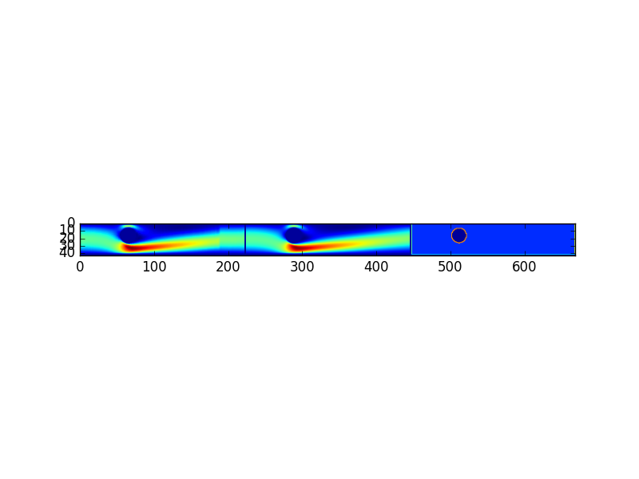

## Methodology

1) We first considered simple case of sphere, did it's CFD analysis and collected data of pressure coordinates.  
2) We used that pressure coordinates at each point to train my model to get that how our model behave.(polar coordinates).  
3) We overlapped the plot of original Pressure coordinate values and model predicted values to get results.

**Results are satisfing enough.**

Parameters of our Geometry.

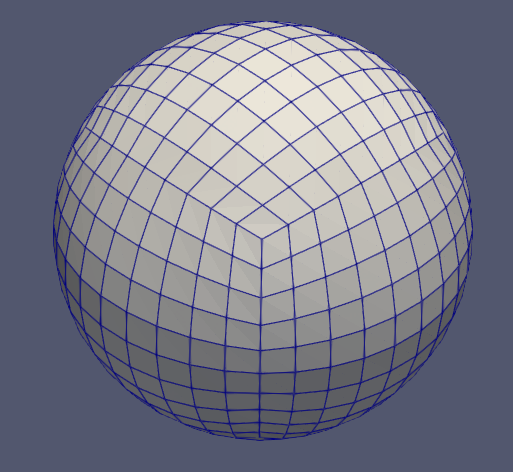

boundingBox: (-0.5 -0.5 -0.5) (0.5 0.5 0.5)  
nPoints: 7351  
nCells: 7000  
nFaces: 21300  
nInternalFaces: 20700

```python
import numpy as np
import matplotlib.pyplot as plt
import pandas as pd
import torch
import sys
```

```python
import sys

IN_COLAB = 'google.colab' in sys.modules
if IN_COLAB:
    from google.colab import drive
    drive.mount('/content/gdrive')
data_file_cap = "/content/gdrive/My Drive/datasetofproject.csv"
```

#### Plotting Input data

```
No handles with labels found to put in legend.
```

```
            px        py
0    -0.157689  0.596598
1    -0.157689  0.596924
2    -0.157689  0.596924
3    -0.158289  0.600586
4    -0.158289  0.600586
...        ...       ...
1165  0.076811  0.622559
1166  0.080411  0.617402
1167  0.081911  0.615234
1168  0.076711  0.622683
1169  0.076811  0.622559

[1170 rows x 2 columns]
The data set contains 1170 points.
```

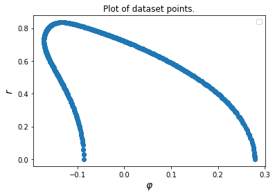

```python
%matplotlib inline
data_cap = pd.read_csv(data_file_cap, header=0)
print(data_cap)
plt.legend()
plt.xlabel(r"$\varphi$", fontsize=14)
plt.ylabel(r"$r$", fontsize=14)
plt.title("Plot of dataset points.")
plt.scatter(list(data_cap['px']),list(data_cap['py']))
print("The data set contains {} points.".format(data_cap.shape[0]))
```

```python
def polar_coordinates(px, py): #this will give polar coordinates
    radius = np.sqrt(np.square(px) + np.square(py))
    theta = np.arccos(py / radius)
    return radius, theta
```

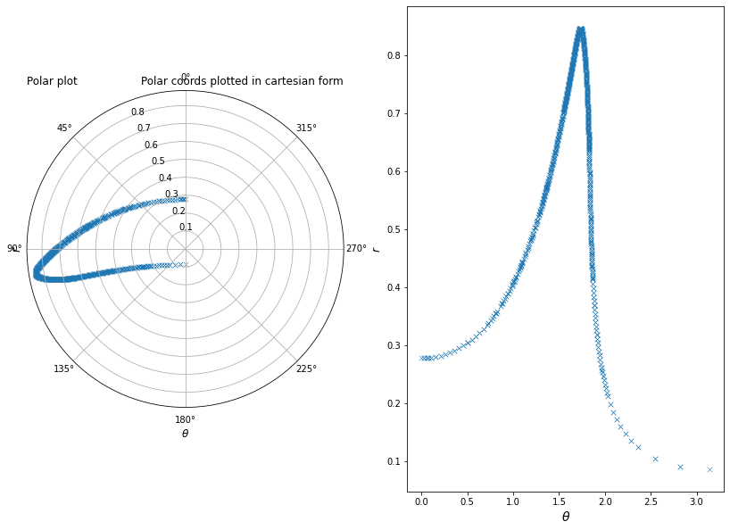

```python
%matplotlib inline
plt.figure(figsize=(14,10))
ax1 = plt.subplot(121, projection='polar')
ax2 = plt.subplot(122)
radius_cap, theta_cap = polar_coordinates(data_cap.py.values, data_cap.px.values)



ax1.set_theta_zero_location("N")
ax1.scatter(theta_cap, radius_cap, marker='x', color='C0', s=30, linewidth=0.5)
ax1.set_xlabel(r"$\theta$", fontsize=12)
ax1.set_ylabel(r"$r$", fontsize=12)
ax1.set_title("Polar plot", loc='left', fontsize=12)




ax2.scatter(theta_cap, radius_cap, marker='x', color='C0', s=30, linewidth=0.5, label=r"spherical cap")
ax2.set_xlabel(r"$\theta$", fontsize=14)
ax2.set_ylabel(r"$r$", fontsize=12)
ax1.set_title("Polar coords plotted in cartesian form", loc='right', fontsize=12)
```

### Creating Model

```python
torch.set_default_tensor_type(torch.DoubleTensor)         # so that more range of number can be stored

class SimpleMLP(torch.nn.Module):
    def __init__(self, n_inputs=1, n_outputs=1, n_layers=1, n_neurons=10, activation=torch.sigmoid):
        super().__init__()
        self.n_inputs = n_inputs
        self.n_outputs = n_outputs
        self.n_layers = n_layers
        self.n_neurons = n_neurons
        self.activation = activation
        self.layers = torch.nn.ModuleList()
        # input layer to first hidden layer
        self.layers.append(torch.nn.Linear(self.n_inputs, self.n_neurons))
        # add more hidden layers if specified
        if self.n_layers > 1:
            for hidden in range(self.n_layers-1):
                self.layers.append(torch.nn.Linear(self.n_neurons, self.n_neurons))
        # last hidden layer to output layer
        self.layers.append(torch.nn.Linear(self.n_neurons, self.n_outputs))
    def forward(self, x):
        for i_layer in range(self.n_layers):
            x = self.activation(self.layers[i_layer](x))
        return self.layers[-1](x)
```

```python
def approximate_function(x, y, model, l_rate=0.001, max_iter=1000, path=None, verbose=100):

    # convert coordinates to torch tensors
    x_tensor = torch.from_numpy(x).unsqueeze_(-1)
    y_tensor = torch.from_numpy(y)
    # define loss function
    criterion = torch.nn.MSELoss()
    # define optimizer
    optimizer = torch.optim.Adam(params=model.parameters(), lr=l_rate)

    # training loop
    best_loss = 1.0E5
    count = 0
    for e in range(1, max_iter+1):
        # backpropagation
        optimizer.zero_grad()
        output = model.forward(x_tensor)
        loss = criterion(output.squeeze(dim=1), y_tensor)
        loss.backward()
        optimizer.step()
        # check error
        diff = output.squeeze(dim=1) - y_tensor
        max_diff = np.amax(np.absolute(diff.detach().numpy()))
        if loss.item() < best_loss:
            count += 1
            best_loss = loss.item()
            if count % verbose == 0:
                print("Loss/max. dev. decreased in epoch {}: {}/{}".format(e, loss.item(), max_diff))
            if path is not None:
                if count % verbose == 0: print("Saving model as {}".format(path))
                torch.save(model.state_dict(), path)
    return model.eval()
```

```python
def set_path(name=None):
    if IN_COLAB:
        return F"/content/gdrive/My Drive/" + name
    else:
        return "models/" + name
```

```python
radius_model_cap_direct = SimpleMLP(n_layers=6, n_neurons=40)

radius_model_cap_direct = approximate_function(theta_cap, radius_cap, radius_model_cap_direct, max_iter=1500,l_rate=0.01 ,path=set_path("radius_model_cap_direct.pt"))
```

```
Loss/max. dev. decreased in epoch 203: 0.026282338084887006/0.561989994041692
Saving model as /content/gdrive/My Drive/radius_model_cap_direct.pt
Loss/max. dev. decreased in epoch 303: 0.02112498151239541/0.5883485600350258
Saving model as /content/gdrive/My Drive/radius_model_cap_direct.pt
Loss/max. dev. decreased in epoch 403: 0.020849955560846074/0.5850113522065156
Saving model as /content/gdrive/My Drive/radius_model_cap_direct.pt
Loss/max. dev. decreased in epoch 553: 0.00014730416010387957/0.10628798986565044
Saving model as /content/gdrive/My Drive/radius_model_cap_direct.pt
Loss/max. dev. decreased in epoch 653: 0.00013036545274362594/0.0959721849628409
Saving model as /content/gdrive/My Drive/radius_model_cap_direct.pt
Loss/max. dev. decreased in epoch 840: 9.352870709347819e-05/0.06169327902252572
Saving model as /content/gdrive/My Drive/radius_model_cap_direct.pt
Loss/max. dev. decreased in epoch 1071: 6.394138964379686e-05/0.023643126300504635
Saving model as /content/gdrive/My Drive/radius_model_cap_direct.pt
Loss/max. dev. decreased in epoch 1232: 5.755882837797481e-05/0.021847604265947174
Saving model as /content/gdrive/My Drive/radius_model_cap_direct.pt
Loss/max. dev. decreased in epoch 1343: 5.358886564032615e-05/0.02056970987066925
Saving model as /content/gdrive/My Drive/radius_model_cap_direct.pt
```

```
Maximum relative deviation for spherical cap: 6.52% at angle 1.92.
```

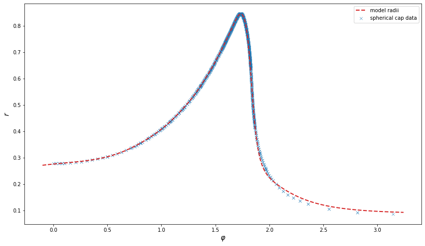

```python
fig, ax = plt.subplots(figsize=(14, 8))

eval_phi = np.linspace(-0.1, np.pi+0.1, 200)
phi_tensor = torch.from_numpy(eval_phi).unsqueeze_(-1)
# load best weights and compute forward pass
radius_model_cap_direct.load_state_dict(torch.load(set_path("radius_model_cap_direct.pt")))
model_radius_cap = radius_model_cap_direct.forward(phi_tensor).detach().squeeze().numpy()
# evaluate maximum relative deviation
phi_cap_tensor = torch.from_numpy(theta_cap).unsqueeze_(-1)
model_radius_cap_data = radius_model_cap_direct.forward(phi_cap_tensor).detach().squeeze().numpy()
diff_cap = np.absolute(model_radius_cap_data - radius_cap)
max_pos_cap = np.argmax(diff_cap)
print(r"Maximum relative deviation for spherical cap: {:2.2f}% at angle {:2.2f}.".format(
      np.amax(diff_cap)/radius_cap[max_pos_cap] * 100, theta_cap[max_pos_cap]))

ax.plot(eval_phi, model_radius_cap, linewidth=2, linestyle="--", c='C3', label=r"model radii")

ax.scatter(theta_cap, radius_cap, marker='x', color='C0', s=30, linewidth=0.5, label=r"spherical cap data")
ax.set_xlabel(r"$\varphi$", fontsize=14)
ax.set_ylabel(r"$r$", fontsize=14)
plt.legend()
plt.show()
```

## Conclusion

As per above graph we can say that Results are satisfactorily.

## References

- Ribeiro, M., Rehman, A., Ahmed, S. & Dengel, A.DeepCFD: Efficient Steady-State Laminar Flow Approximation with Deep Convolutional Neural Networks.. arXiv:2004.08826 [physics.comp-ph]
- Hanna, Botros N.., Dinh, Nam T.., Youngblood, Robert W.. & Bolotnov, Igor A..Machine-learning based error prediction approach for coarse-grid Computational Fluid Dynamics (CG-CFD).. https://doi.org/10.1016/j.pnucene.2019.103140
- AndreWeiner/machine-learning-applied-to-cfd: Examples of how to use machine learning algorithms in computational fluid dynamics...